# CBFI Tutorial

Sejong Oh

2021. 10. 07.

## 1. Introduction

Feature importance and interaction are among the main issues in explainable artificial intelligence or interpretable machine learning. CBFI (Prediction Case based-Feature importance and interaction) package is for observing feature importance and interaction for given prediction model. It supports both classification and regression model. This tutorial shows usages of functions that CBFI supports.

## 2. Install CBFI package

To install CBFI package, you may be required Rtoools SW. In that case, you can get get Rtoools at https://cran.r-project.org/bin/windows/Rtools/.

After install CBFI package, please restart R session.

```r
install.packages(
  "https://bitldku.github.io/home/sw/CBFI/CBFI_1.0.0.tar.gz",
  repos = NULL, type = "source")

#.rs.restartR()  # restart R session

library(CBFI)   # load CBFI package
```

## 3. Datasets and prediction models for test

In this tutorial, We use two datsets, Bostion and iris for regression and classification, respectively. ‘lm’ and ‘svm’ functions are used for building prediction models.

### [Build a regression model on Boston dataset]

```r
data(Boston, package='MASS')
head(Boston)    # medv is a target variable
```

```
##      crim zn indus chas   nox    rm  age    dis rad tax ptratio  black lstat
## 1 0.00632 18  2.31    0 0.538 6.575 65.2 4.0900   1 296    15.3 396.90  4.98
## 2 0.02731  0  7.07    0 0.469 6.421 78.9 4.9671   2 242    17.8 396.90  9.14
## 3 0.02729  0  7.07    0 0.469 7.185 61.1 4.9671   2 242    17.8 392.83  4.03
## 4 0.03237  0  2.18    0 0.458 6.998 45.8 6.0622   3 222    18.7 394.63  2.94
## 5 0.06905  0  2.18    0 0.458 7.147 54.2 6.0622   3 222    18.7 396.90  5.33
## 6 0.02985  0  2.18    0 0.458 6.430 58.7 6.0622   3 222    18.7 394.12  5.21
##   medv
## 1 24.0
## 2 21.6
## 3 34.7
## 4 33.4
## 5 36.2
## 6 28.7
```

```r
model.lm <- lm(medv~., data=Boston)
summary(model.lm)
```

```
##
## Call:
## lm(formula = medv ~ ., data = Boston)
##
## Residuals:
##     Min      1Q  Median      3Q     Max
## -15.595  -2.730  -0.518   1.777  26.199
##
## Coefficients:
##               Estimate Std. Error t value Pr(>|t|)
## (Intercept)  3.646e+01  5.103e+00   7.144 3.28e-12 ***
## crim        -1.080e-01  3.286e-02  -3.287 0.001087 **
## zn           4.642e-02  1.373e-02   3.382 0.000778 ***
## indus        2.056e-02  6.150e-02   0.334 0.738288
## chas         2.687e+00  8.616e-01   3.118 0.001925 **
## nox         -1.777e+01  3.820e+00  -4.651 4.25e-06 ***
## rm           3.810e+00  4.179e-01   9.116  < 2e-16 ***
## age          6.922e-04  1.321e-02   0.052 0.958229
## dis         -1.476e+00  1.995e-01  -7.398 6.01e-13 ***
## rad          3.060e-01  6.635e-02   4.613 5.07e-06 ***
## tax         -1.233e-02  3.760e-03  -3.280 0.001112 **
## ptratio     -9.527e-01  1.308e-01  -7.283 1.31e-12 ***
## black        9.312e-03  2.686e-03   3.467 0.000573 ***
## lstat       -5.248e-01  5.072e-02 -10.347  < 2e-16 ***
## ---
## Signif. codes:  0 '***' 0.001 '**' 0.01 '*' 0.05 '.' 0.1 ' ' 1
##
## Residual standard error: 4.745 on 492 degrees of freedom
## Multiple R-squared:  0.7406, Adjusted R-squared:  0.7338
## F-statistic: 108.1 on 13 and 492 DF,  p-value: < 2.2e-16
```

In the Boston dataset, ‘medv’ is the target variable.

### [Build a classification model on iris dataset]

```r
head(iris)
```

```
##   Sepal.Length Sepal.Width Petal.Length Petal.Width Species
## 1          5.1         3.5          1.4         0.2  setosa
## 2          4.9         3.0          1.4         0.2  setosa
## 3          4.7         3.2          1.3         0.2  setosa
## 4          4.6         3.1          1.5         0.2  setosa
## 5          5.0         3.6          1.4         0.2  setosa
## 6          5.4         3.9          1.7         0.4  setosa
```

```r
library(e1071)  # for svm
model.svm <- svm(Species~., data=iris)
summary(model.svm)
```

```
##
## Call:
## svm(formula = Species ~ ., data = iris)
##
##
## Parameters:
##    SVM-Type:  C-classification
##  SVM-Kernel:  radial
##        cost:  1
##
## Number of Support Vectors:  51
##
##  ( 8 22 21 )
##
##
## Number of Classes:  3
##
## Levels:
##  setosa versicolor virginica
```

## 4. Feature importance plot

Feature importance measures the extent to which a feature or variable influences the prediction results of a given model. A predictive model is built on multiple features, wherein each feature makes a unique contribution to the prediction. A model can be better understood by having knowledge of the influence of each feature in the model.

### [For classification model]

Feature importance plot on iris dataset. More iteration (itr) produces more accurate result.

```r
result <- CB_FeatureImp(model.svm, train=iris, target.name="Species", itr=50, task="classification")
```

If your computer has multi-core, you can use parallel processing option. Please set ‘parallel=T’ and put package name that model classifier belongs to. This option also can be applied to regression task.

```r
result <- CB_FeatureImp(model.svm, train=iris, target.name="Species", itr=50, task="classification", parallel=T, pkg="e1071")
```

```r
print(result)
```

```
## $task
## [1] "classification"
##
## $overall
##         class      feature     cont_F1 cont_other cont_common     interact
## 13      _all_ Sepal.Length 0.002000000 0.64293333  0.31373333 0.0146666667
## 14      _all_  Sepal.Width 0.011333333 0.61000000  0.31413333 0.0378666667
## 15      _all_ Petal.Length 0.017866667 0.33706667  0.38080000 0.2376000000
## 16      _all_  Petal.Width 0.094800000 0.28653333  0.36866667 0.2233333333
## 1      setosa Sepal.Length 0.000000000 0.21586667  0.10666667 0.0108000000
## 4      setosa  Sepal.Width 0.001466667 0.21213333  0.11866667 0.0010666667
## 7      setosa Petal.Length 0.000000000 0.15200000  0.10720000 0.0741333333
## 10     setosa  Petal.Width 0.000000000 0.16133333  0.10666667 0.0653333333
## 2  versicolor Sepal.Length 0.000000000 0.21226667  0.10720000 0.0005333333
## 5  versicolor  Sepal.Width 0.003733333 0.19640000  0.10520000 0.0146666667
```

[output cut: 25 more lines]

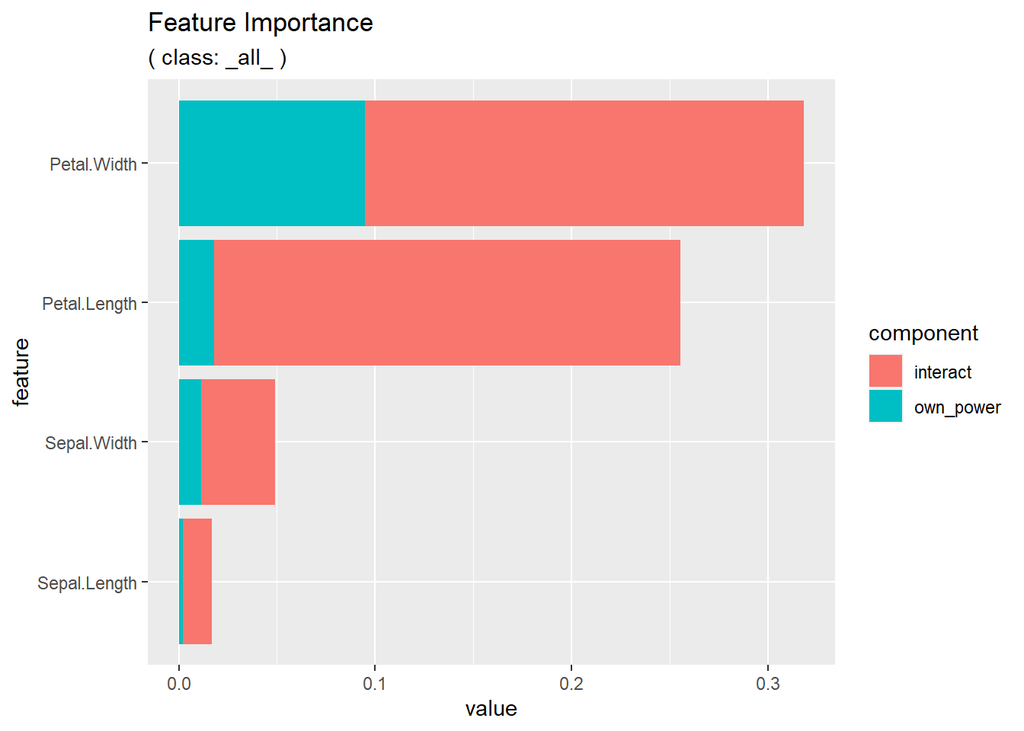

```r
CB_plot.imp(result, class="_all_")
```

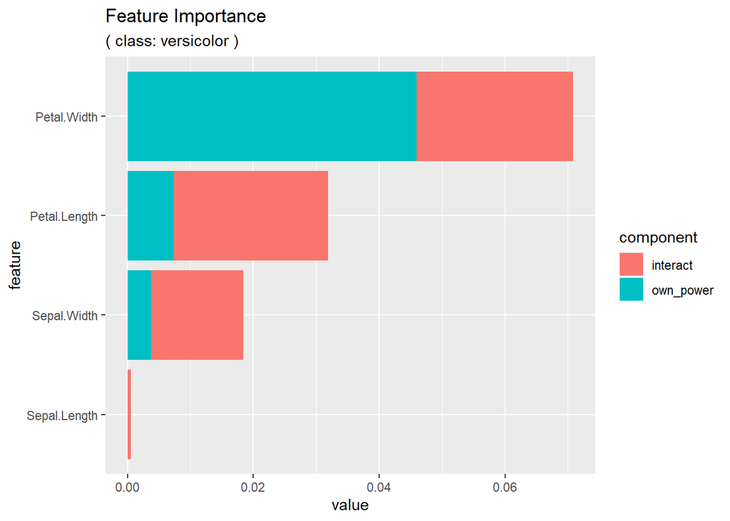

```r
CB_plot.imp(result, class="versicolor")
```

In the proposed method, feature importance can be decompsed into ‘feature power’ and ‘interaction power’.

### [For regression model]

Feature importance plot on Boston dataset.

```r
result <- CB_FeatureImp(model.lm, train=Boston, target.name="medv", itr=50, task="regression")
```

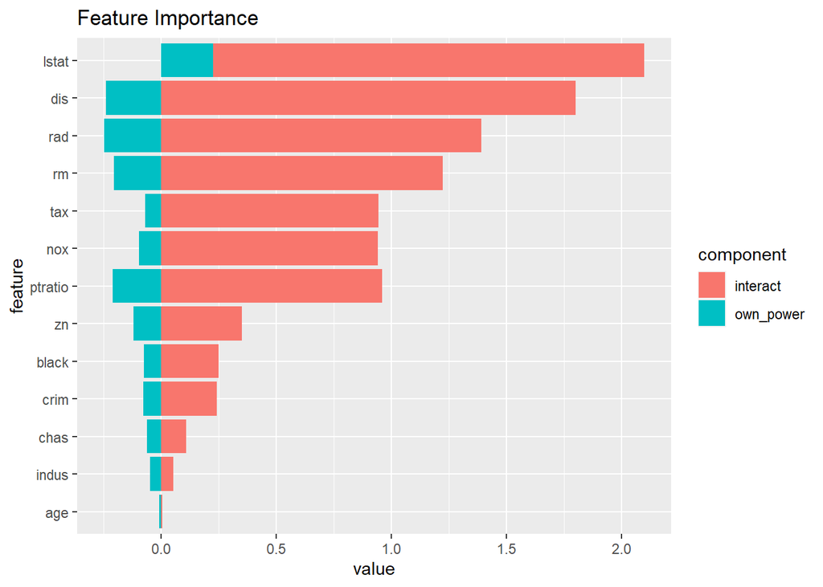

```r
CB_plot.imp(result, combine=F)
```

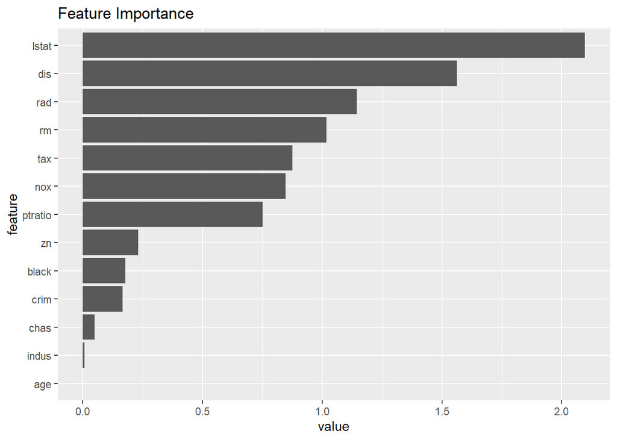

```r
CB_plot.imp(result, combine=T)
```

## 5. Feature interaction plot

The features of a predictive model tend to collaborate in a prediction task, which indicates the presence of feature interactions.

### [For classification model]

Feature interaction plot for between two features in iris dataset. CB_FeatureInteract function has parallel processing option. See CB_FeatureImp.

```r
result <- CB_FeatureInteract(model.svm, train=iris, target.name="Species", F1="Petal.Width", F2=NULL, itr=50, task="classification")
```

```
## End class:  setosa ...
## End class:  versicolor ...
## End class:  virginica ...
```

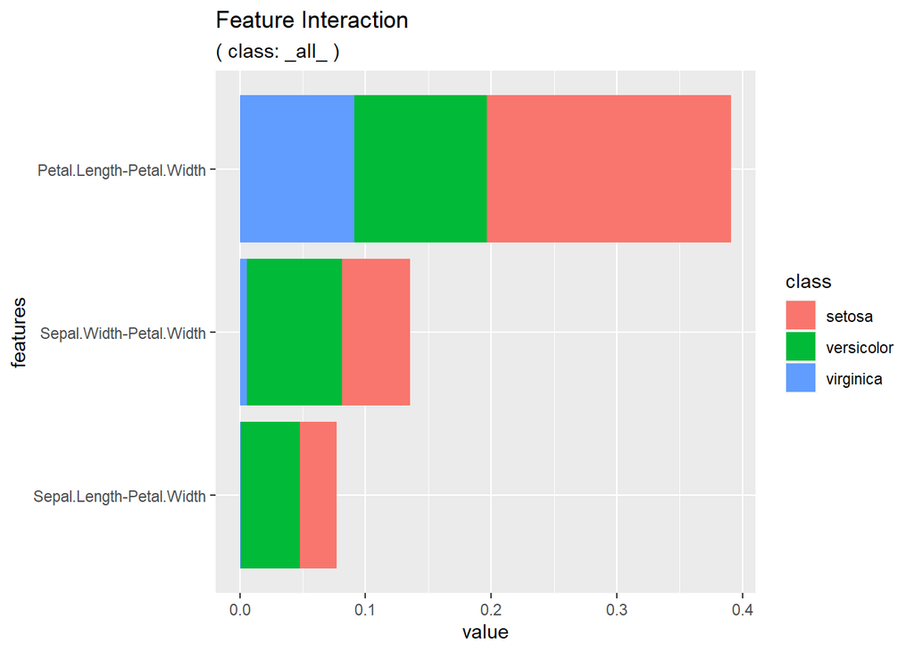

```r
CB_plot.interact(result, class="_all_")
```

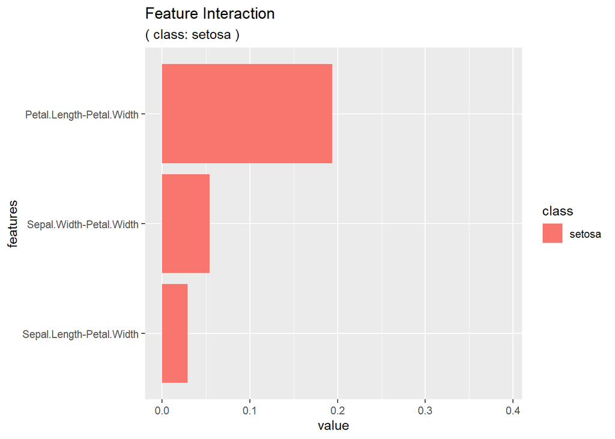

```r
CB_plot.interact(result, class="setosa")
```

```r
result2 <- CB_FeatureInteract(model.svm, train=iris, target.name="Species", F1="Petal.Width", F2="Petal.Length", itr=50, task="classification")
```

```
## End class:  setosa ...
## End class:  versicolor ...
## End class:  virginica ...
```

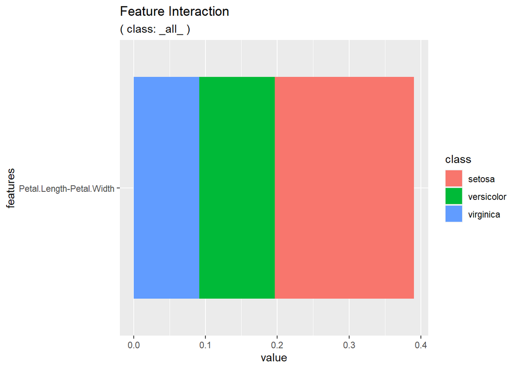

```r
CB_plot.interact(result2, class="_all_")
```

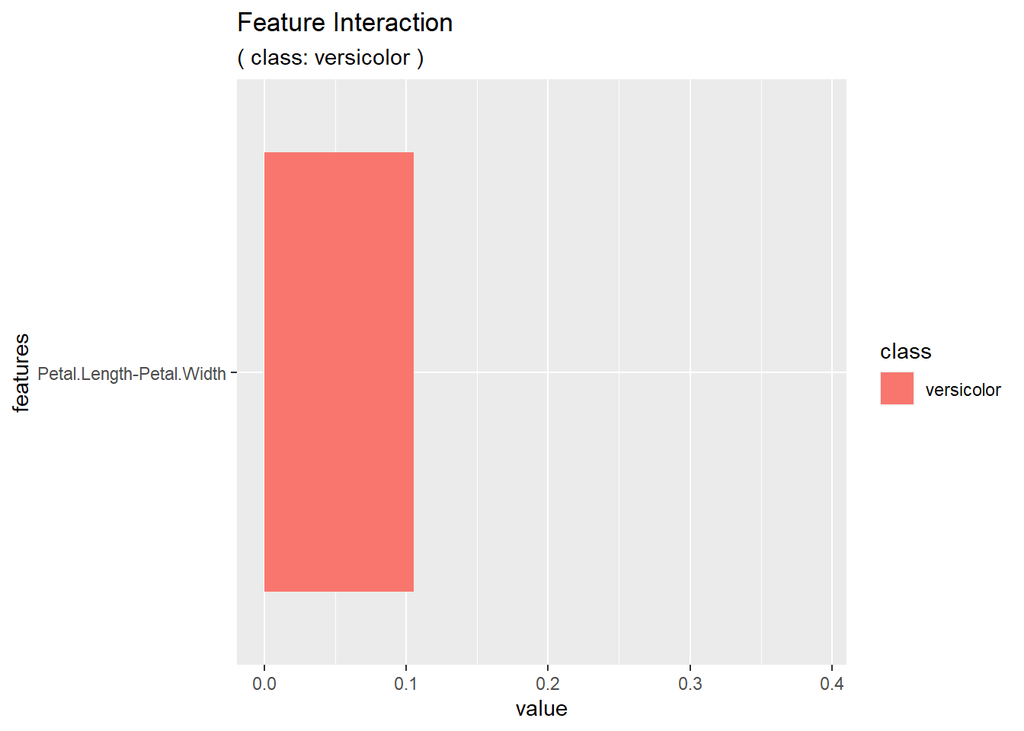

```r
CB_plot.interact(result2, class="versicolor")
```

### [For regression model]

Feature interaction plot for between two features in Boston dataset.

```r
result <- CB_FeatureInteract(model.lm, train=Boston, target.name="medv", F1="lstat", F2=NULL, itr=50, task="regression")
```

```r
print(result)
```

```
## $task
## [1] "regression"
##
## $data
##    class feature1 feature2  interact cont_F1 cont_F2 cont_common
## 1     NA    lstat     crim 1.3351777      NA      NA          NA
## 2     NA    lstat       zn 0.7226682      NA      NA          NA
## 3     NA    lstat    indus 0.2734015      NA      NA          NA
## 4     NA    lstat     chas 0.2241101      NA      NA          NA
## 5     NA    lstat      nox 1.1386733      NA      NA          NA
## 6     NA    lstat       rm 1.7710637      NA      NA          NA
## 7     NA    lstat      age 0.3252661      NA      NA          NA
## 8     NA    lstat      dis 0.5060150      NA      NA          NA
## 9     NA    lstat      rad 0.2866776      NA      NA          NA
## 10    NA    lstat      tax 1.2288722      NA      NA          NA
## 11    NA    lstat  ptratio 1.5476454      NA      NA          NA
## 12    NA    lstat    black 0.9745014      NA      NA          NA
```

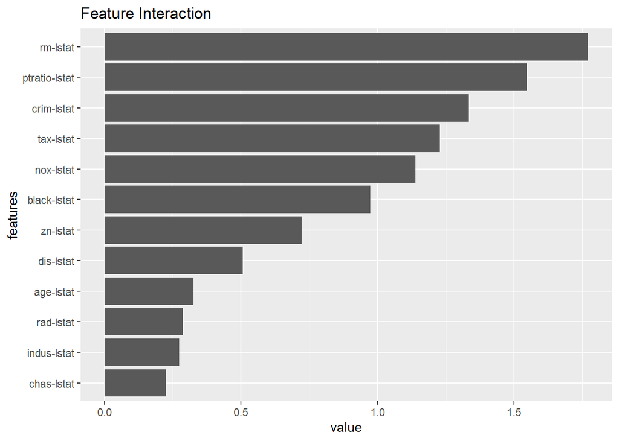

```r
CB_plot.interact(result)
```

```r
result2 <- CB_FeatureInteract(model.lm, train=Boston, target.name="medv", F1="lstat", F2="rm", itr=50, task="regression")
```

```r
print(result2)
```

```
## $task
## [1] "regression"
##
## $data
##   class feature1 feature2 interact cont_F1 cont_F2 cont_common
## 1    NA    lstat       rm 1.771064      NA      NA          NA
```

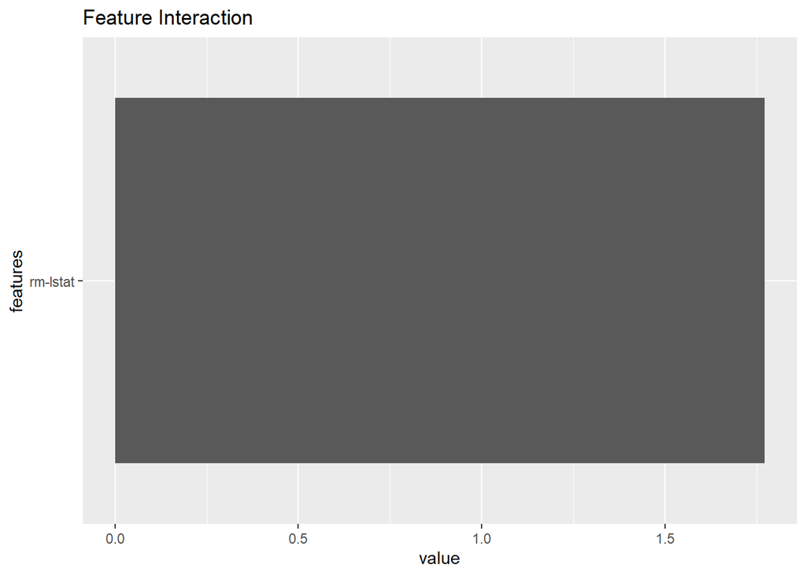

```r
CB_plot.interact(result2)
```

## 6. Feature interaction network

The purpose of the feature interaction graph is to visualize the overall feature interaction in a predictive model. A graph is composed of nodes (or vertices) and edges. In the proposed feature interaction graph, a node and an edge represent a feature and an interaction between the two features, respectively. The size of a node is defined by its importance. The color of a node is defined by the importance of the feature.

### [For classification model]

```r
FIobj <- CB_FItable(model.svm, iris, "Species", itr=50, task="classification")
```

```
## th:  0.1456667
```

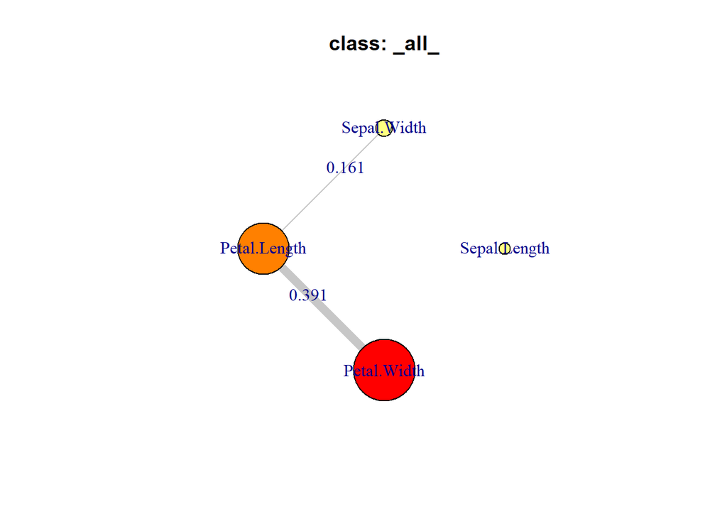

```r
# print(FIobj)
CB_plot.FIgraph( gtype="S", FIobj=FIobj, task="classification", class="_all_",
             show.edge.weight=TRUE, seed=104)
```

```
## th:  0.066
```

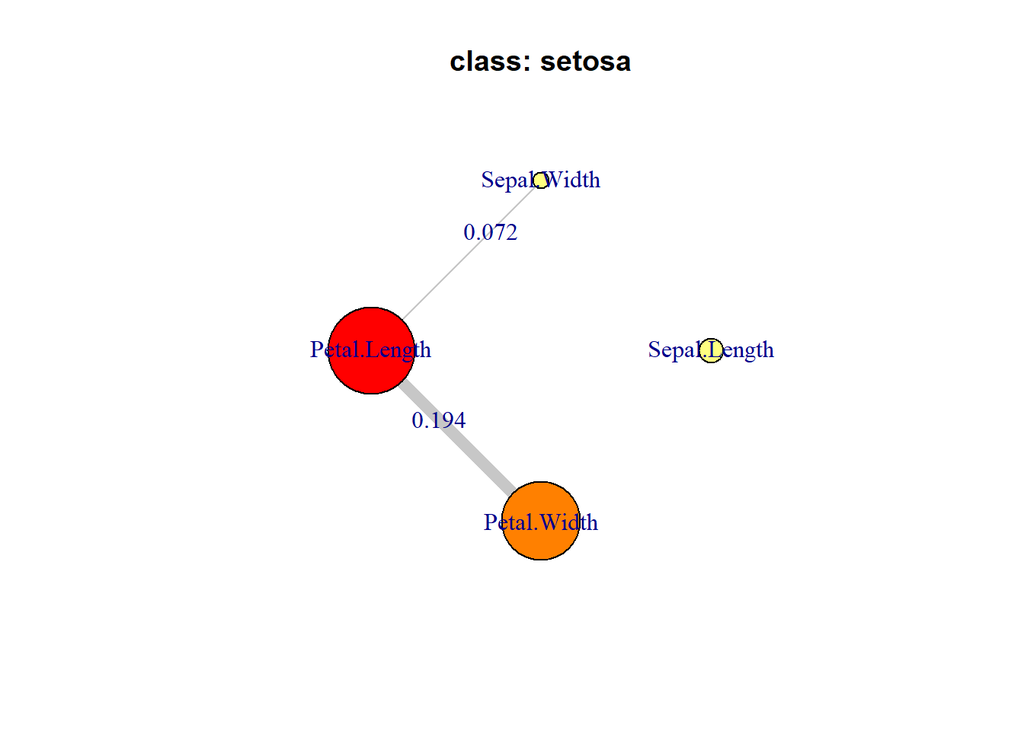

```r
CB_plot.FIgraph( gtype="S", FIobj=FIobj, task="classification", class="setosa",
             show.edge.weight=TRUE, seed=104)
```

### [For regression model]

```r
FIobj <- CB_FItable(model.lm, Boston, "medv", itr=50, task="regression")
```

CB_FItable function has parallel processing option. See CB_FeatureImp.

```
## th:  0.4065256
```

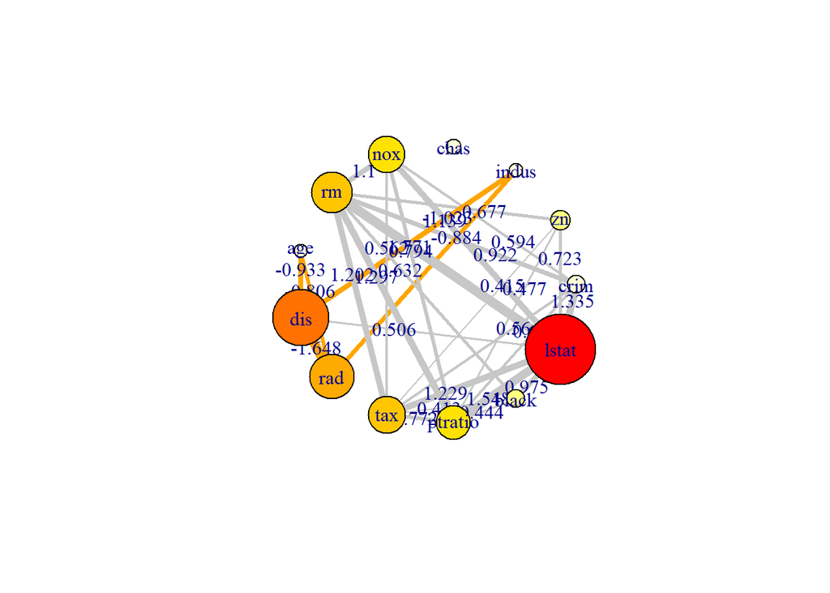

```r
# print(FIobj)
CB_plot.FIgraph(gtype="S", FIobj, task="regression", class="_all_",
                    show.edge.weight=TRUE, seed=104, th=NULL)
```

```r
# Interactive plot
# CB_plot.FIgraph(gtype="I", FIobj, task="regression", class="_all_",
#                    show.edge.weight=TRUE, seed=104, th=NULL)
#
```

Please ignore warning error after drawing interactive graph.

## 7. Prediction analysis plot

The purpose of the prediction analysis chart is to show who contributes correctly predicted cases in an instance when two features are bound. This is similar to the scatter plot.

### [For classification model]

```
## [1] "generate data for plot ...."
```

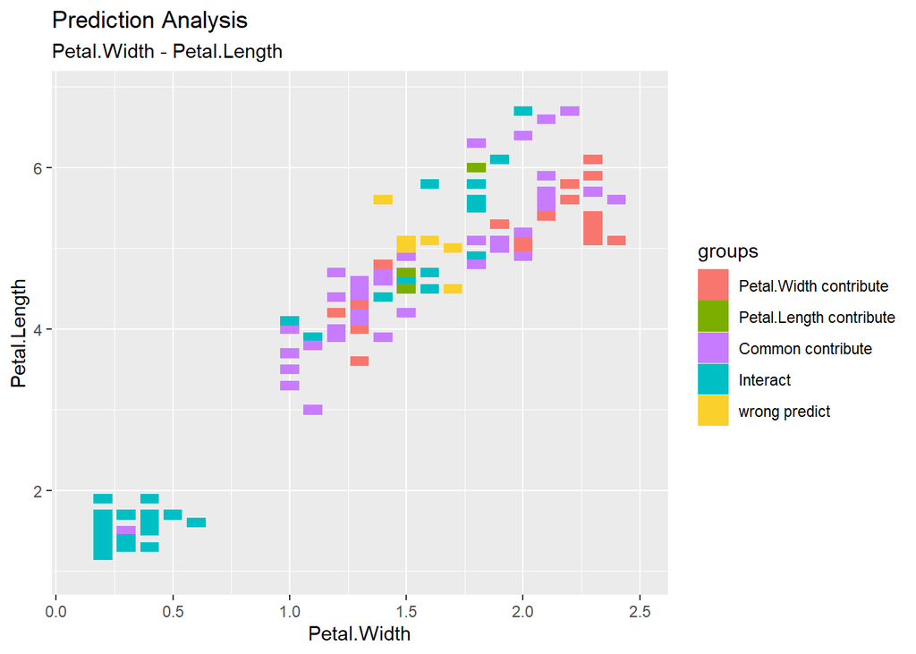

```r
CB_plot.PA(model.svm, iris, "Species", F1="Petal.Width", F2="Petal.Length", itr=10, task="classification")
```

```
## [1] "generate data for plot ...."
```

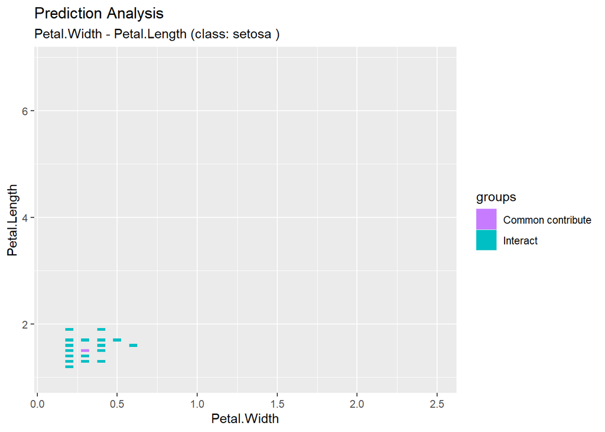

```r
CB_plot.PA(model.svm, iris, "Species", F1="Petal.Width", F2="Petal.Length", itr=10, task="classification", class="setosa")
```

### [For regression model]

```
## [1] "generate data for plot ...."
```

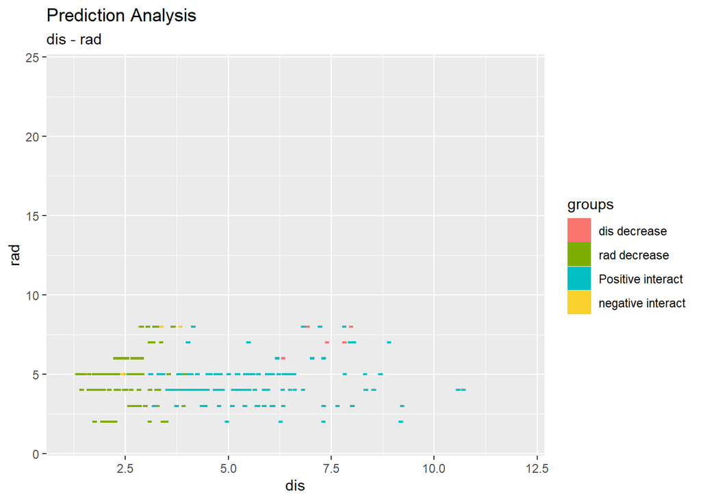

```r
CB_plot.PA(model.lm, Boston, "medv", F1="dis", F2="rad", itr=10, task="regression")
```

```
## [1] "generate data for plot ...."
```

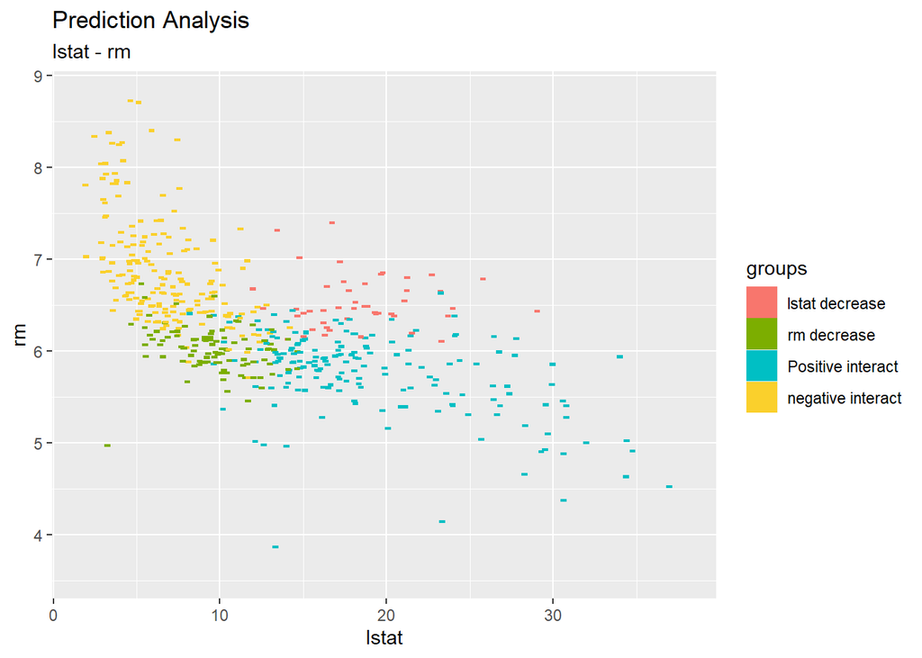

```r
CB_plot.PA(model.lm, Boston, "medv", F1="lstat", F2="rm", itr=10, task="regression")
```

## 8. Feature contribution plot

In general, the binding of two features, improves prediction accuracy. The feature contribution chart shows the size of contribution or interaction of the two features, in the improvement of prediction accuracy.

### [For classification model]

```r
result = CB_FeatureInteract(model.svm, iris, "Species",  F1="Petal.Width", F2="Petal.Length", itr=10, task="classification")
```

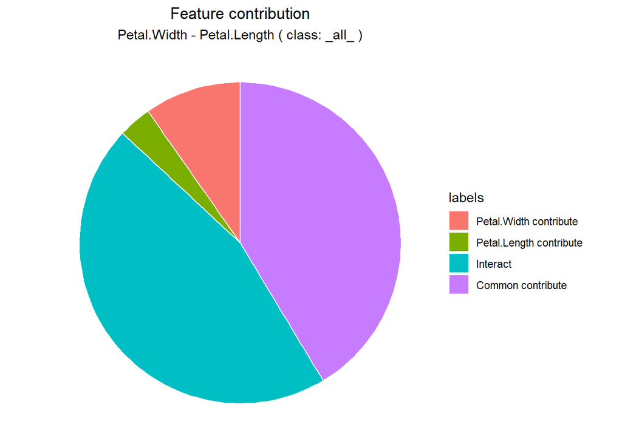

```r
CB_plot.contribute(result, class="_all_")
```

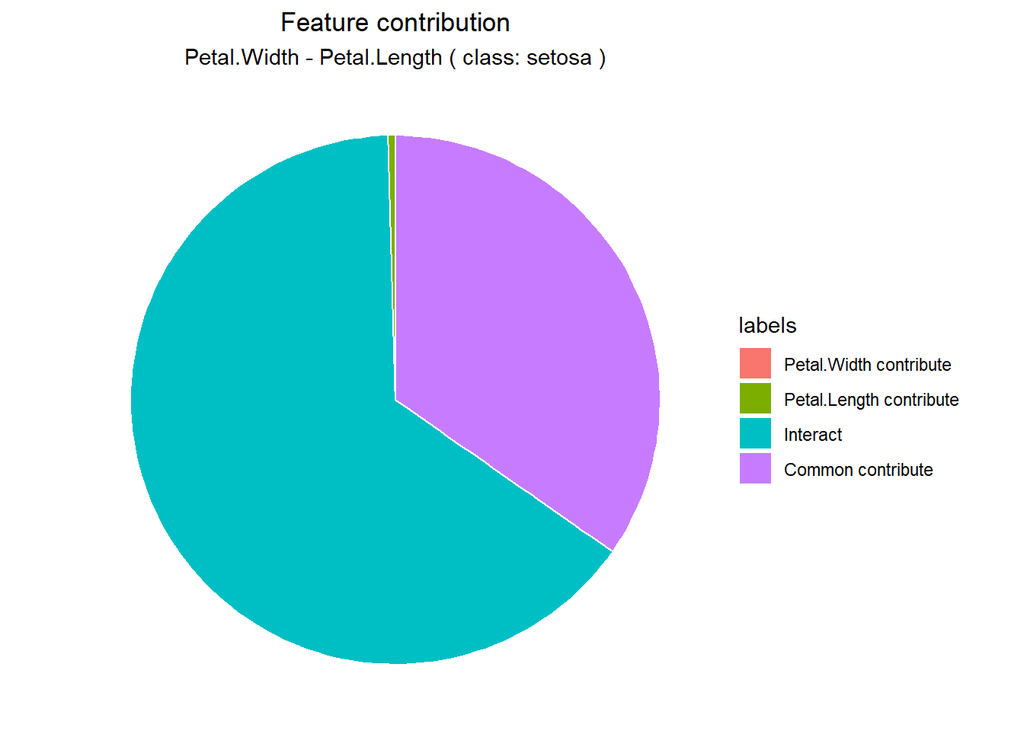

```r
CB_plot.contribute(result, class="setosa")
```